# The pair distribution function (PDF)

What is the definition of PDF? How to calculate PDF?

## The definition of R(r)

Radial distribution function: how many pairs of atoms are there at distance $r$ in a unit volume multiplied by a weight.

$$\large R(r) = \frac{1}{N} \sum_{u} \sum_{v} \frac{f_u f_v}{\bar{f}^2} \delta(r - r_{uv})$$

The integral is the number of atoms in the structure.

$$\large \int_{0}^{\infty} R(r) dr = N$$

## The definition of G(r)

Pair distribution function: how different is the density of atomic pairs at distance $r$ from the average.

$$\large G(r) = \frac{R(r)}{r} - 4{\pi}\rho_0r \text{, in 3D space}$$$$\large G(r) = \frac{R(r)}{r} - 2{\pi}\rho_0 \text{, in 2D space}$$$$\large G(r) = \frac{R(r)}{r} - \frac{2\rho_0}{r} \text{, in 1D space}$$

The integral is zero.

$$\large \int_{0}^{\infty} G(r) r dr = 0$$

## An example: 2D square crystal

Every atom has the same scattering factor so the weights are 1.

$$ \large R(r) = \frac{1}{N} \sum_{u} \sum_{v} \frac{f_u f_v}{\bar{f}^2} \delta(r - r_{uv}) = \sum_{v} \delta(r - r_{0v}) $$

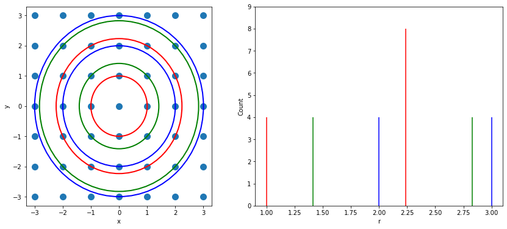

## Uncertainity in positions

The atoms randomly deviate from the lattice sites and the deviation follows normal distribution. The peaks change from delta functions to Gaussian functions.

$$\large R(r) = \sum_{v} \frac{1}{\sigma\sqrt{2\pi}} \exp(-\frac{(r - r_{0v})^2}{2\sigma^2})$$

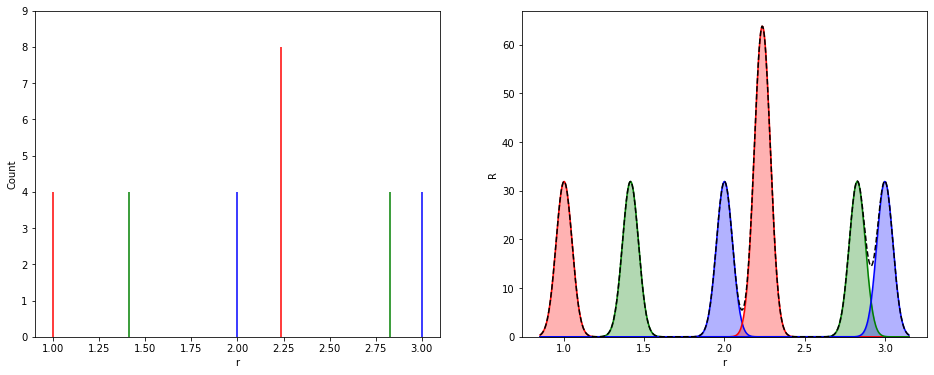

## R(r) and G(r) of a square crystal

$$\large G(r) = \frac{R(r)}{r} - 2{\pi}\rho_0$$

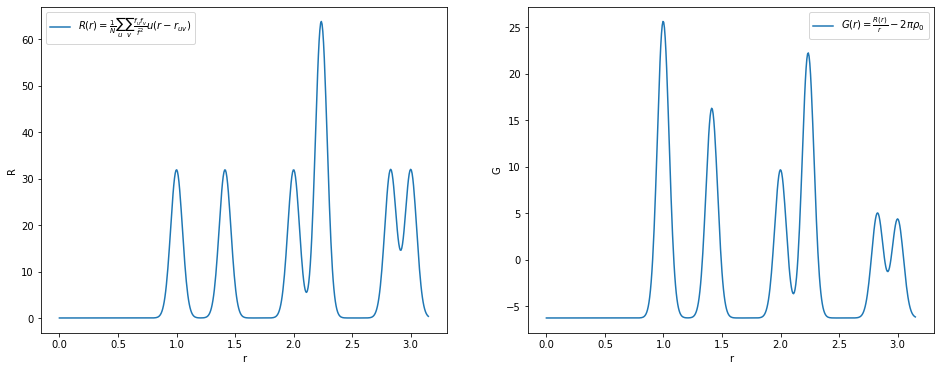

## Baselines of R(r) and G(r) in 2D space

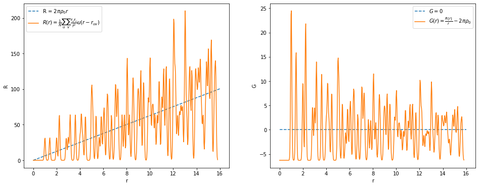

## Modeling of G(r): cost function

$$f(p_0, p_1, ... , p_n) = \frac{1}{2} \chi^2(p_0, p_1, ... , p_n)$$$$\chi^2(p_0, p_1, ... , p_n) = \int_0^{\infty} \left[ \frac{G_{obs}(r) - G_{cal}(r, p_0, p_1, ... , p_n)}{\Delta G_{obs}(r)} \right] ^2 dr$$$$G_{cal}(r, p_0, p_1, ... , p_n) = F(Structure(p_0, p_1, ... , p_n))$$

Usually, we don't know $\Delta G_{obs}(r)$ so we assume $\Delta G_{obs}(r) = 1$.

## An example: G(r) of a square crystal

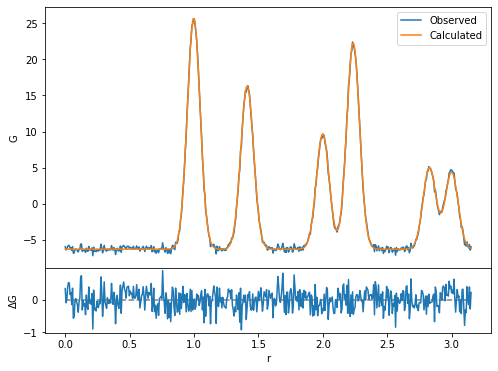

## Modeling of G(r): small box

A small box model is one lattice or one small super lattice. For example, a square crystal has a square lattice with four atoms at corners.

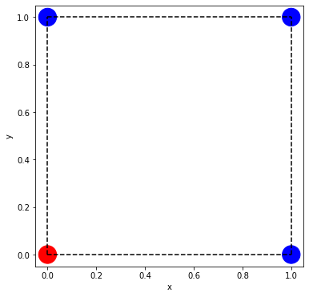

## Modeling of G(r): small box + gradient descent

[figure not shown]

## Modeling of G(r): big box

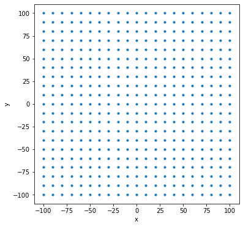

## Modeling of G(r): big box + reverse monte carlo

[figure not shown]

## Discussion

What are the forms of R(r) and G(r) in 4D Euclidean space? What are the baselines like?

What if the space has curvature? For exmaple, when you are doing PDF measurement near a black hole, what equations will you use to calculate PDF?

Why do we use G(r) in our researches instead of R(r) which has a well-defined physics meaning?